# Class 2

March 29, 2017

## Welcome

## Welcome Back !

These slides: http://www.databrew.cc/class2

## How was the homework?

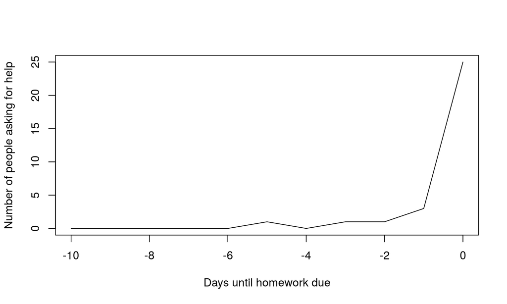

## Difficulty

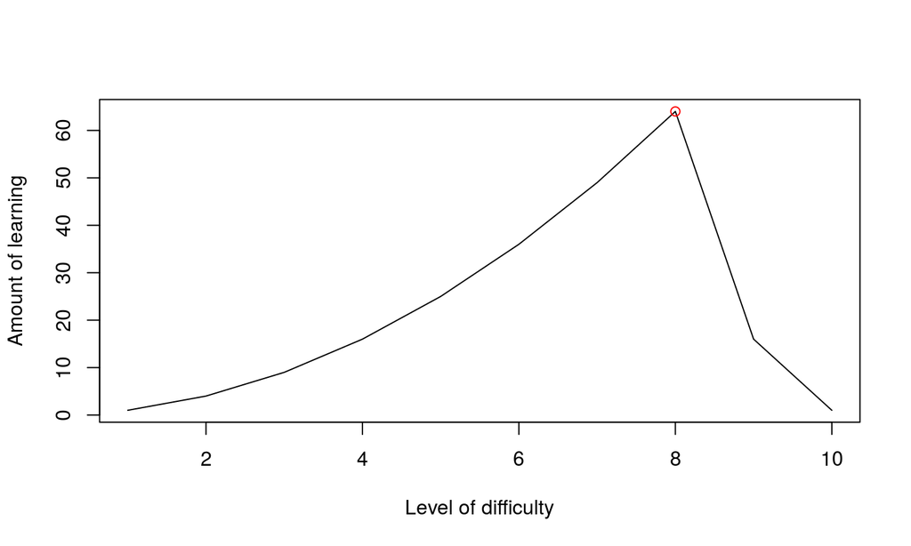

```r
x <- 1:10
y <- c(1:8, 4, 1)^2
plot(x, y,
     type = 'l',
     xlab = 'Level of difficulty',
     ylab = 'Amount of learning')
points(x = 8, y = 8^2,
       col = 'red')
```

## For next homework

- Ask for help!
- Ask early.
- Ask often.

## Review of rules

- Be on time (class starts at 15:00 exactly)
- Do your homework
- Ask for help

## Review

```r
frangos <- databrew::frangos
```

## Census

```r
census <- databrew::census
```

## Some questions

1. How many people in the data have a motorcycle.
2. Make a table called `floors` without the different types of floor materials.
3. Make a barplot of the `floors` table.
4. Make a dataframe of only those people without floors.
5. Make a map of only those people without floors.

## Some more questions

1. Make a map of *all* people using `cism_map`, and color the map by the "floor_material" variable.
2. Make a map of only those people without floors, and color the map by the "sex" variable.
3. Make a table called `xt`. This will be a cross-table of the "moto" and "bike" variables.
4. Use `chisq.test` on the `xt` table to see if their is a significant correlation between having a motorcycle and having a bike.

## Analysis

## Getting data

We're going to use the `cism` package to get weather data for the `FQMA` weather station (Maputo).

```r
library(cism)
library(data.table)
```

```r
??get_weather
```

## Getting data

```r
weather <- get_weather(station = 'FQMA',
                       start_year = 2010,
                       end_year = 2017)
```

## Exploring data

Now that we have our weather data, we can look at it.

```r
head(weather)
```

## Exploring data

Now that we have our weather data, we can look at it.

```r
head(weather)
```

```
        date temp_max temp_mean temp_min humidity_max humidity_mean
1 2010-01-01       34        30       26           94            66
2 2010-01-02       31        27       24           89            72
3 2010-01-03       32        28       24           94            79
4 2010-01-04       31        26       21          100            84
5 2010-01-05       25        23       21          100            82
6 2010-01-06       28        24       20           83            69
  humidity_min precipitation cloud_cover location
1           52             0           2     FQMA
2           55             0           5     FQMA
3           55             0           6     FQMA
4           58             0           6     FQMA
5           65             0           6     FQMA
6           54             0           3     FQMA
```

## Some questions on our data

1. How many rows are in our data?
2. How many columns?
3. What are the names of the columns?

## Some questions on our data

```r
# 1. How many rows are in our data?
nrow(weather)
# 2. How many columns?
ncol(weather)
# 3. What are the names of the columns?
colnames(weather)
```

## Some questions on our data

```r
# 1. How many rows are in our data?
nrow(weather)
```

```
[1] 2383
```

## Some questions on our data

```r
# 2. How many columns?
ncol(weather)
```

```
[1] 10
```

## Some questions on our data

```r
# 3. What are the names of the columns?
colnames(weather)
```

```
 [1] "date"          "temp_max"      "temp_mean"     "temp_min"
 [5] "humidity_max"  "humidity_mean" "humidity_min"  "precipitation"
 [9] "cloud_cover"   "location"
```

## Questions about specific columns

1. What is the date range?
2. What is the maximum temperature?
3. What is the minimum temperature?
4. What is the average temperature?

## Questions about specific columns

```r
# 4. What is the date range?
range(weather$date)
# 5. What is the maximum temperature?
max(weather$temp_max)
# 6. What is the minimum temperature?
min(weather$temp_min)
# 7. What is the average temperature?
mean(weather$temp_mean)
```

## Questions about specific columns

```r
# 4. What is the date range?
range(weather$date)
```

```
[1] "2010-01-01" "2017-03-03"
```

## Questions about specific columns

```r
# 5. What is the maximum temperature?
max(weather$temp_max, na.rm = TRUE)
```

```
[1] 44
```

## Questions about specific columns

```r
# 6. What is the minimum temperature?
min(weather$temp_min, na.rm = TRUE)
```

```
[1] 7
```

## Questions about specific columns

```r
# 7. What is the average temperature?
mean(weather$temp_mean, na.rm = TRUE)
```

```
[1] 23.97527
```

## Visualizing our data

Which variables do we have which are *numeric and continuous*?

How can we visualize these?

## Visualizing our data

Which variables do we have which are *numeric and continuous*?

- `temp_max`, `temp_mean`, `temp_min`, etc…

How can we visualize these?

- boxplot, histogram

## Boxplot

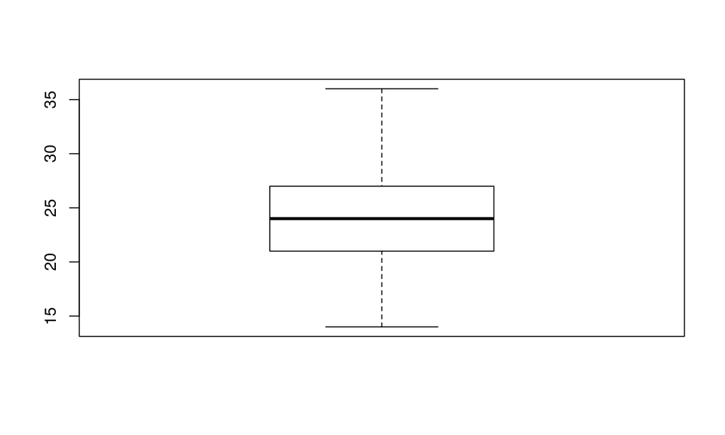

```r
boxplot(weather$temp_mean)
```

## Histogram

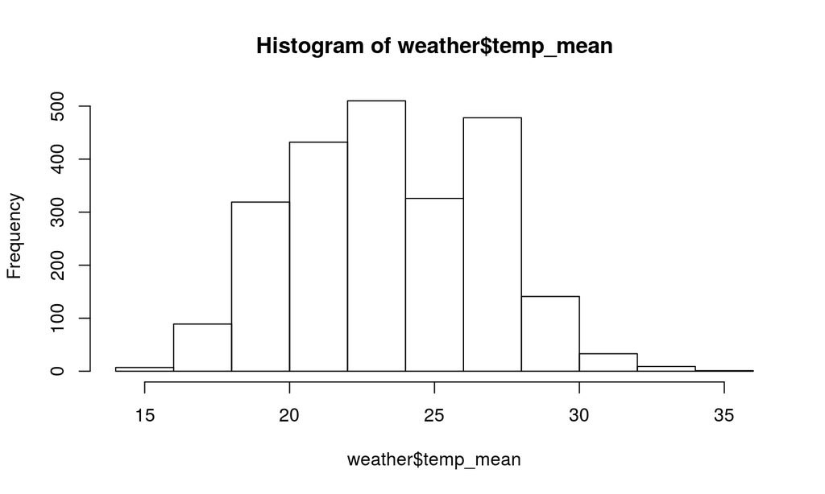

```r
hist(weather$temp_mean)
```

## Creating new variables

Let's create a variable called "hot"

## Creating new variables

```r
weather$hot <- ifelse(weather$temp_max > 30, 'hot', 'not hot')
```

## Creating new variables

```r
head(weather)
```

## Creating new variables

```r
head(weather)
```

```
        date temp_max temp_mean temp_min humidity_max humidity_mean
1 2010-01-01       34        30       26           94            66
2 2010-01-02       31        27       24           89            72
3 2010-01-03       32        28       24           94            79
4 2010-01-04       31        26       21          100            84
5 2010-01-05       25        23       21          100            82
6 2010-01-06       28        24       20           83            69
  humidity_min precipitation cloud_cover location     hot
1           52             0           2     FQMA     hot
2           55             0           5     FQMA     hot
3           55             0           6     FQMA     hot
4           58             0           6     FQMA     hot
5           65             0           6     FQMA not hot
6           54             0           3     FQMA not hot
```

## Exploring our new variable

```r
table(weather$hot)
hot_table <- table(weather$hot)
hot_prop_table <- prop.table(hot_table)
```

## Exploring our new variable

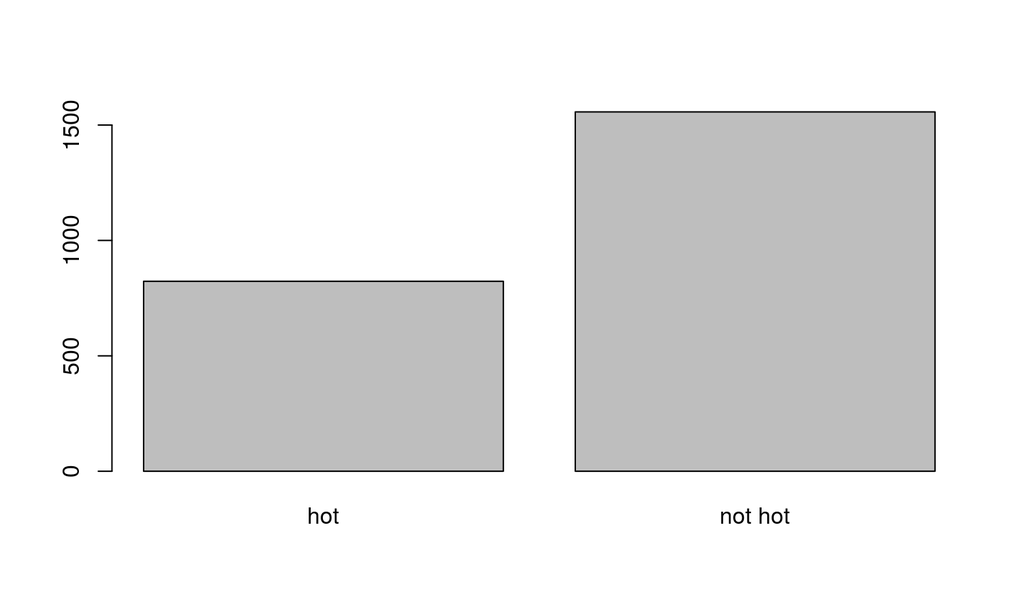

```r
hot_table <- table(weather$hot)
hot_prop_table <- prop.table(hot_table)
barplot(hot_table)
```

## Making our plot prettier

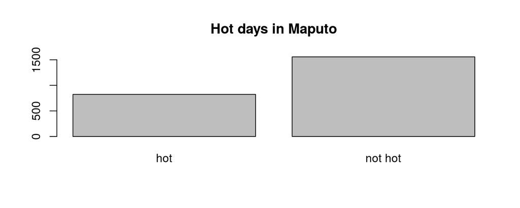

```r
barplot(hot_table,
        main = 'Hot days in Maputo')
```

## Making our plot prettier

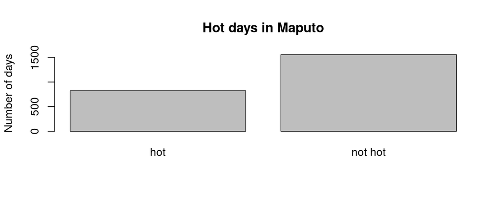

```r
barplot(hot_table,
        main = 'Hot days in Maputo',
        ylab = 'Number of days')
```

## Making our plot prettier

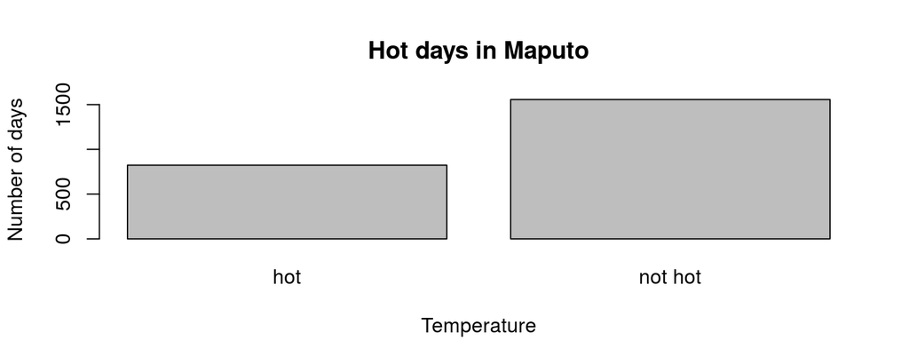

```r
barplot(hot_table,
        main = 'Hot days in Maputo',
        ylab = 'Number of days',
        xlab = 'Temperature')
```

## Making our plot prettier

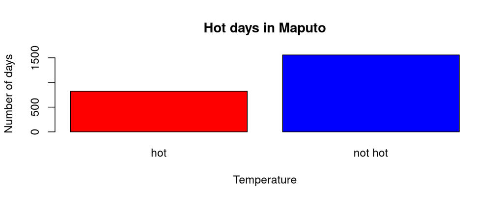

```r
barplot(hot_table,
        main = 'Hot days in Maputo',
        ylab = 'Number of days',
        xlab = 'Temperature',
        col = c('red', 'blue'))
```

## Making our plot prettier

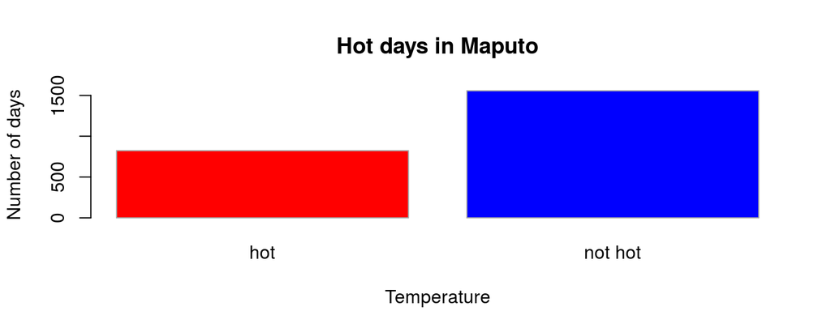

```r
barplot(hot_table,
        main = 'Hot days in Maputo',
        ylab = 'Number of days',
        xlab = 'Temperature',
        col = c('red', 'blue'),
        border = 'darkgrey')
```

## Now let's do the same for `rainy`

1. Create the variable
2. Tabulate it.
3. Barplot it.

## Some questions

1. What was the maximum temperature in last 7 years?
2. What was the minimum temperature in the last 7 years?

## Multi-variable plots

Let's create a plot of date (x-axis) and the maximum temperature

## Multi-variable plots

Let's create a plot of date (x-axis) and the maximum temperature

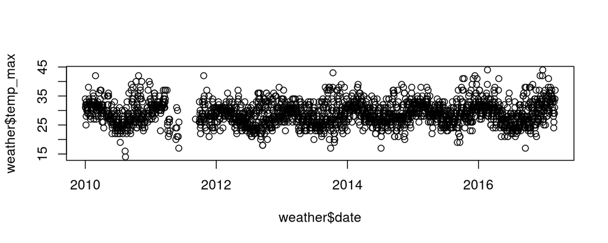

```r
plot(weather$date,
     weather$temp_max)
```

## Multi-variable plots

Let's make our plot prettier

## Multi-variable plots

Let's make our plot prettier

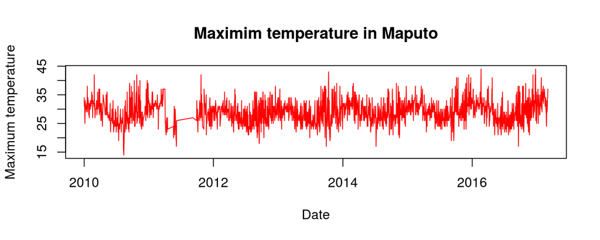

```r
plot(weather$date,
     weather$temp_max,
     type = 'l',
     col = 'red',
     xlab = 'Date',
     ylab = 'Maximum temperature',
     main = 'Maximim temperature in Maputo')
```

## Where is joe?

## Where is Joe

We're going to analyze where Joe is, using data from google. The data is part of the `databrew` package.

```r
# Load package
library(databrew)

# Get data
joe <- joe
```

## Where is Joe

Let's have a look at the structure of our data.

```r
head(joe)
```

```
        date                time longitude  latitude velocity altitude
1 2017-03-13 2017-03-13 11:08:06  32.79699 -25.40760       NA       NA
2 2017-03-13 2017-03-13 11:06:01  32.79699 -25.40760       NA       NA
3 2017-03-13 2017-03-13 11:05:32  32.80439 -25.40608       NA       NA
4 2017-03-13 2017-03-13 11:03:03  32.80439 -25.40608       NA       NA
5 2017-03-13 2017-03-13 11:01:03  32.80545 -25.40844       NA       NA
6 2017-03-13 2017-03-13 11:00:16  32.80545 -25.40779       NA       NA
  heading accuracy
1      NA     2500
2      NA     2500
3      NA     1899
4      NA     1899
5      NA      400
6      NA      699
```

## Where is Joe

Let's filter our data so that it only contains observations for the period from March 7-13.

```r
joe_filtered <- joe[joe$date >= '2017-03-07' &
                      joe$date <= '2017-03-13',]
```

## Where is Joe

Now let's use the `cism` package to plot Manhiça.

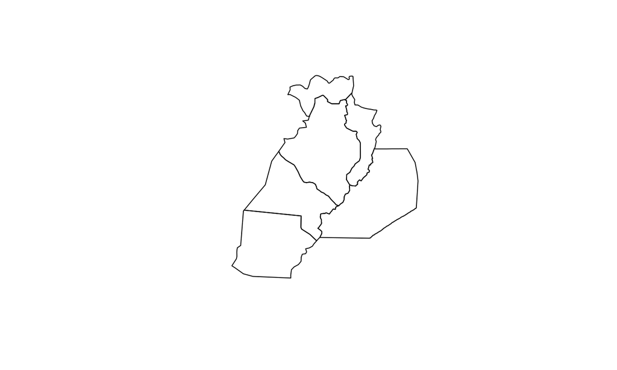

```r
library(cism)
library(sp)
manhica <- man3
plot(manhica)
```

## Where is Joe

The `databrew` package has a nice function called `visualize_location`. Let's try it out

```r
?visualize_location
```

## Where is Joe

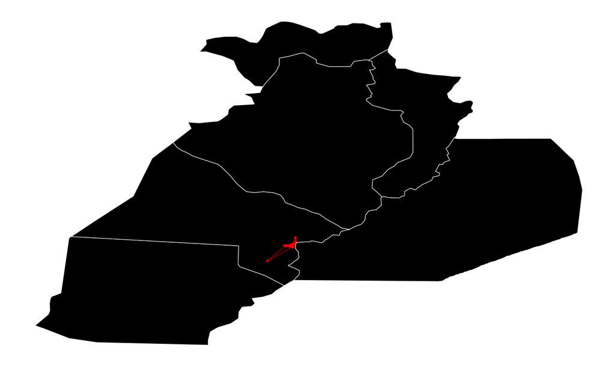

```r
visualize_location(x = joe_filtered,
                   spdf = manhica)
```

## Where is Joe

Let's also try with an interactive map

```r
visualize_location(x = joe_filtered,
                   use_leaflet = TRUE)
```

[interactive chart not shown]

## More weather

## Create a variable for month

```r
weather$month <- format(weather$date, '%m')
```

## Create a variable for year

```r
weather$year <- format(weather$date, '%Y')
```

## Introducing the `dplyr` package

`dplyr` is very useful

```r
library(dplyr)
```

## Get the average temperature per month

```r
x <-
  weather %>%
  group_by(month) %>%
  summarise(average_temperature = mean(temp_mean, na.rm = TRUE))
```

## Visualization of average temperature

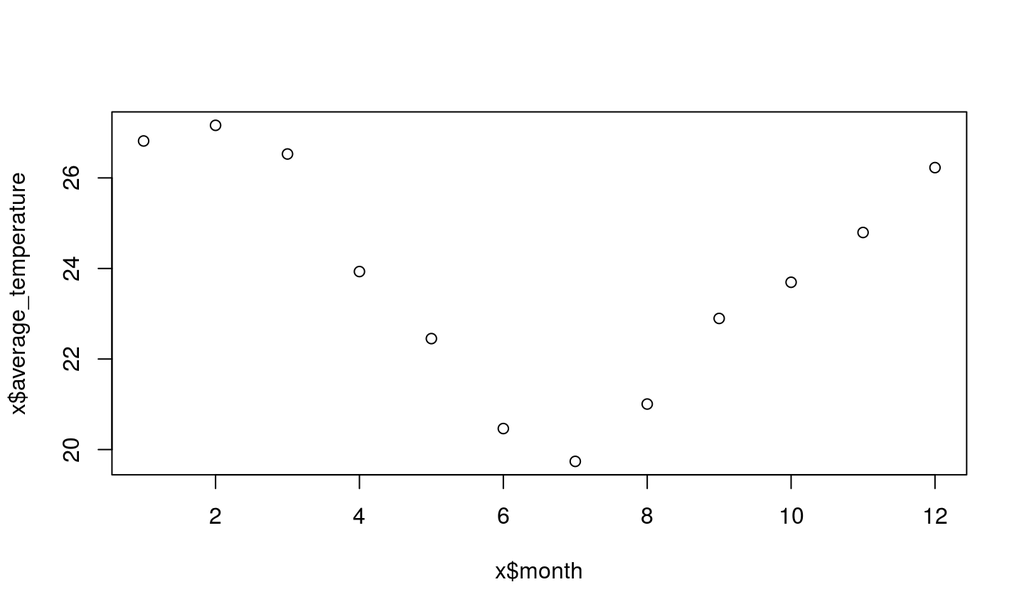

```r
plot(x = x$month,
     y = x$average_temperature)
```

## Get and visualize the average daily max temperature per month

1. Create an object called `y`
2. In that object, group by month and get max temperature
3. Make a plot

## Creating lots of variables in dplyr